# UN ANALISI SU FILM E RELATIVI SEQUEL

## Motivazioni:

- Un film ogni sera;
- Vedere il mondo del cinema con spirito critico;
- Lato oggettivo nella valutazione dei film.

## Domande a cui rispondere:

- Qual è la relazione tra il budget e gli incassi per i film e i loro sequel?
- C'è una correlazione tra il numero di voti su IMDb e il successo al botteghino?
- Quali generi di film originali sono più redditizi?
- Quali generi tendono a produrre i sequel più redditizi?
- Quali sono i generi più longevi in termini di numero di sequel?
- Come cambiano i rating IMDb tra i film originali e i sequel?
- Che relazione c'è tra i guadagni dei film originali e sequel negli anni?

## Dati utilizzati

Il dataset utilizzato è il seguente: [Movies with Sequels: IMDb Analytics and Ratings](https://www.kaggle.com/datasets/thedevastator/movies-with-sequels-imdb-analytics-and-ratings)

- Il dataset è aggiornato a 2 anni fa per cui mancano i dati sui film più recenti
- Al dataset mancano dati importanti per un'analisi approfondita quali budget e incassi, differenza tra incassi e budget; distinzione tra sequel e film originali e identificazione dei generi per ciascun film
- Per l'analisi però questi dati mancanti sono stati aggiunti, dati inutilizzati sono: Description, Created, Modify, Const, Position, Title Type.

## I dati:

- Position: Indice del film
- Const: Identificatore unico film
- Created: Data creazione film su IMDB
- Modified: Data modifica film su IMDB
- Description: Descrizione breve del film
- Title: Titolo Film
- URL: Link film su IMDB
- Title Type: film o serie
- IMDb Rating: valutazione su IMDB
- Runtime (mins): durata del film in minuti
- Year: Anno di rilascio del film
- Genres: generi del film
- Num Votes: numero di voti ricevuti su IMBD
- Release Date: Data di rilascio del film
- Directors: regista del film

## Budget e incassi dei film e i sequel

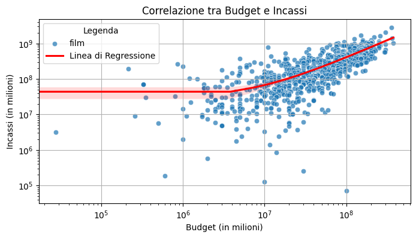

All'aumentare del budget aumentano anche gli incassi, pochi casi isolati identificano una correlazione negativa, per cui un budget più grande non comporta necessariamente maggiori incassi.

## Numero di voti su IMDb e il successo al botteghino

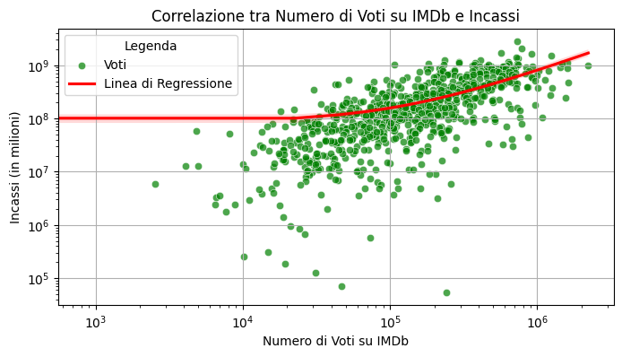

Film con un gran numero di voti tendono ad avere maggiori incassi, pochi outlier identificano i film con pochi voti ma comunque con incassi elevati (correlazione scarsa)

## Generi di film originali più redditizi

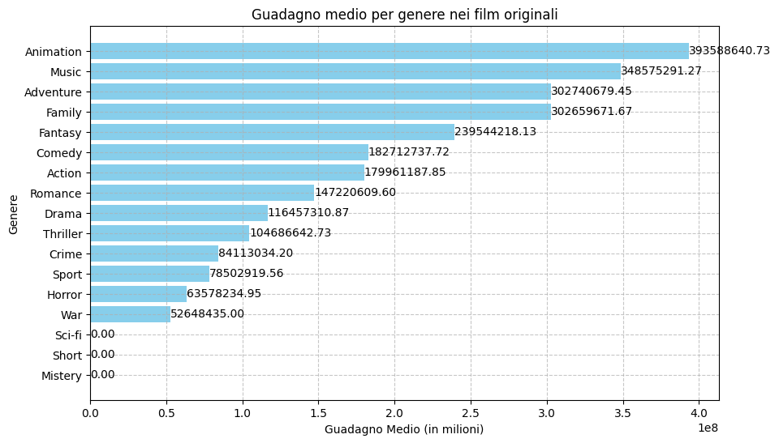

Domina il genere Animazione al primo posto, genere Musicale al secondo, genere Avventura al terzo.

## Generi di sequel più redditizi

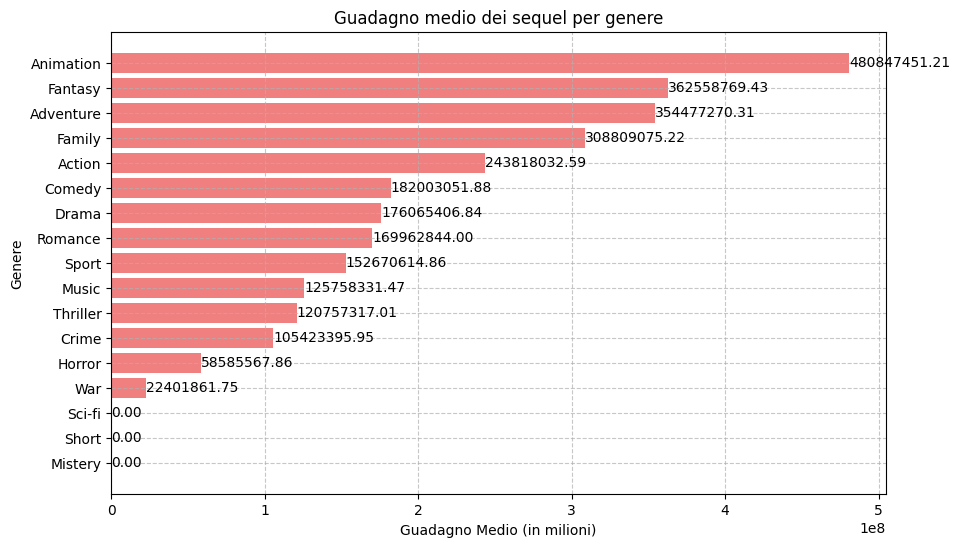

Domina il genere Animazione in prima posizione, Fantasy in seconda e Avventura in terza.

## Generi film originali e sequel più redditizi insieme

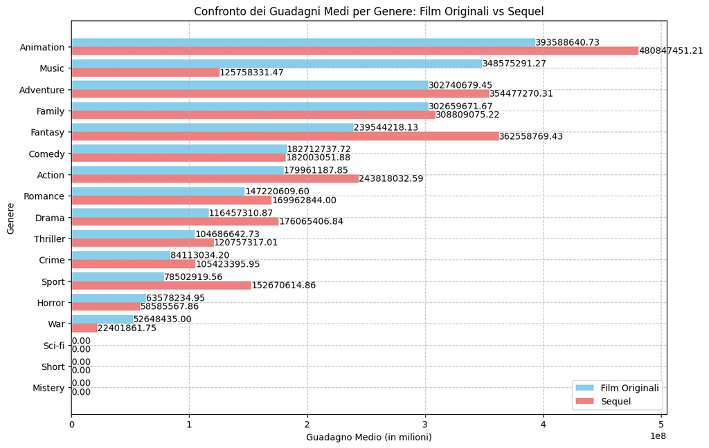

I guadagni maggiori provengono dai sequel: incassi elevati per il genere animazione, eccetto per il genere musicale, commedia, horror e guerra.

## Generi più longevi in termini di numero di sequel

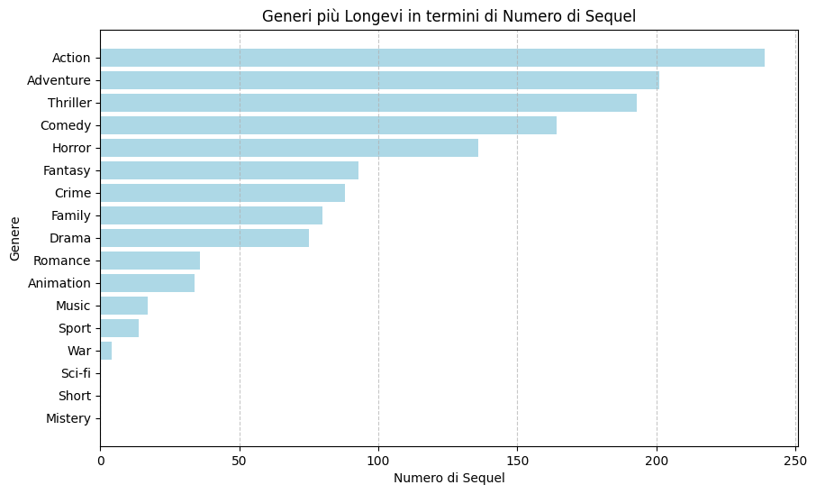

I generi Action, Adventure, Thriller, Comedy, Horror sono quelli che dominano in termini di sequel ma il loro successo com'è in relazione a ciò? (prossima slide)

## Longevità vs Guadagno medio per genere

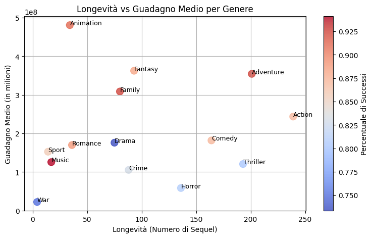

Maggiore la longevità in termini di sequel non è direttamente proporzionale a maggiori guadagni, ad esempio il genere Animazione ha molti guadagni ma offre meno sequels, il genere avventura è quello più bilanciato (tanti sequel e buoni incassi).

## Rating IMDb tra i film originali e i sequel

[figure not shown]

Il rating IMDb per i film originali è maggiore di quello per i sequel.

## Guadagni dei film originali e dei sequel negli anni

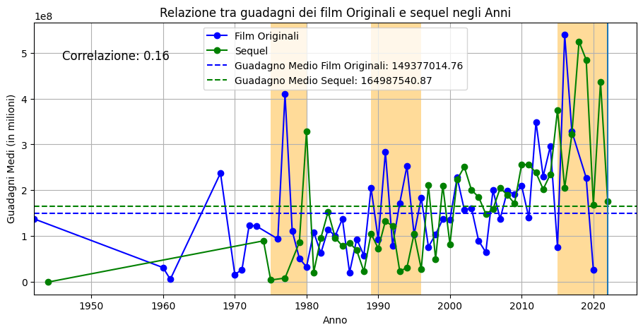

Bassa correlazione tra guadagno medio dei film originali e sequel, le fascie arancione indicano punti dove c'è grande differenza tra i due grafici: 1975-1980 più successo film originali; 1989-1996 più successo film originali; 2015-2022 più successo i sequel.

## Conclusioni

Dall'analisi ho atratto le seguenti conclusioni:

- Un maggior budget e un maggior numero di voti corrispondono a maggiori incassi
- Il genere dell'Animazione è il più redditizio sia per i film originali che per i sequel
- Il genere Azione è più longevo nei sequel ma ha minori incassi, viceversa l'Animazione ha pochi sequel ma molti incassi (il genere Avventura è quello più bilanciato, tanti sequel e buoni incassi)
- Le valutazioni IMBd sono migliori per i film originali rispetto ai sequel ma i guadagni maggiori provengono da questi ultimi.

L'obbiettivo di avere una panoramica sui sequel attraverso un'analisi dei dati è stato soddisfatto, va però considerato che le analisi sui generi non sono assolute poichè un film può avere più generi.